# Basic File Input

INEG 2214: Computing Methods for INEG I

## Introduction

All computer programs rely on information for analysis. Thus far, the information utilized in our programs have been obtained from the user via a computer keyboard and our results have been displayed to the user via the console window. However, processing large amounts of information require the use of input files and the ability to store the results in output files for later analysis. This document demonstrates one approach to basic file input and input in `java`.

## Components of File Input

In this section we offer the key components needed to read a file. Note that these considerations are implemented in the order provided. We assume that the location of the data file you wish to read is known. Specifically, all input files will be located in a directory named *data* directly within our IntelliJ project folder.

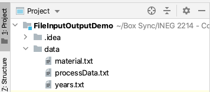

The first step in reading an input file is to create a `FileInputStream` object that specifies the path of the input file to read.

```java
FileInputStream fis = new FileInputStream("data/years.txt");
```

Note that the `FileInputStream` class requires that a `FileNotFoundException` exception be thrown if the file path specified is not valid. We will discuss exceptions later in the course. For now, know that any method that makes use of the `FileInputStream` class requires the phrase `throws FileNotFoundException` at the end of the method signature. For example, a `main` method that contains a `FileInputStream` object would be defined as follows.

```java
public static void main(String[] args) throws FileNotFoundException {
}
```

Next, create a `Scanner` object used to read values from an input file when the `FileInputStream` object is provided as an argument at initialization, as shown below.

```java
Scanner scnr = new Scanner(FileInputStream object name);
```

Finally, a value is read from the file using the name of the `Scanner` object with name of the method used to read the data type value associated with the information being read.

```java
variableType variableName = scanner_object_name.nextDataType();
```

## Basic File Input Example

The following example reads integer values from a file named *years.txt* located in the *data* directory of the IntelliJ project. The `while` loop determines if there is another value in the file to read. If the condition of the `while` loop evaluates true, the value is read and stored in the integer variable `nextValue`. The value is printed to the screen to confirm that the values are being read in corrrectly.

```java
FileInputStream fis = new FileInputStream("data/years.txt");
Scanner scnr = new Scanner(fis);

while (scnr.hasNextInt()) {
  int nextValue = scnr.nextInt();
  System.out.println(nextValue);
}
```

The output from this example is included below.

```java
1996
1998
2011
2019
2021
```

## Basic File Input Exercise

The file *processData.txt* includes floating point values associated with the diameter of the last 1,000 washers produced from a production line. The quality specifications of the production line state that if the diameter of more than 2 out of 1,000 washers exceeds 1 inch then the production line must be stopped and maintenance performed. Using the file provided, add code to the `BasicInputExercise` class that reads the values from the file, completes the necessary analysis and reports to the user whether the production line should be stopped.

## Reading Multiple Values Per Line

### Multiple Reads Per Line

If the developer knows how many values on each line of an input file and the type of data associated with each value, code can be written to read each value from a line separately. For example, to read material name, value and units, a user can utilize a call to the `next()`, `nextDouble()`, and `nextInt()` methods, respectively, of the `Scanner` class to read and assign these values to the appropriate variable. As when reading single values on each line, a `while` loop controls the iteration through each row of information in the file. The code block below shows a full implementation of reading three values per line until all three row of information has been read.

```java
FileInputStream fis = new FileInputStream("data/material.txt");
Scanner scnr = new Scanner(fis);

String materialName = "";
double materialValue = 0.0;
int materialUnits = 0;

while (scnr.hasNext()) {
      materialName = scnr.next();
      materialValue = scnr.nextDouble();
      materialUnits = scnr.nextInt();
      System.out.printf("%s %.1f %d%n", materialName, materialValue, materialUnits);
}
```

### Split Line of Input

In the previous implementation, multiple values per line were read by a separate method of the `Scanner` call for each value. Alternatively, a developer can read an entire line of input and split that line of input into individual values using a specified delimeter. The parsed line of input is stored in an `Array` of `String` objects. Each `String` object can be parsed to the desired data type. To illustrate, consider again the example in which a material name, material value, and units of material are read from a line of input. In the code block below an entire row of input is read in as a `String` and split into the `String` array named `inputLine` using the `split()` method of the `String` class. In this example the split method is given a space as an argument. This indicates that the `String` should be separated using a space as the delimeter. The result of split operation on the first line of input in *materials.txt* is:

$$inputline[] = \{``Steel",``3.8",``4"\}$$

The value of `inputLine[0]` is “Steel”, `inputLine[1]`, is “3.8”, and `inputLine[2]`is “4”. To convert the `String` “3.8” to a `double` the developer uses either`Double.valueOf(inputLine[1]` (deprecated) or `Double.parseDouble(inputLine[1])`. To convert the `String` “4” to an `int` the developer uses either `Integer.valueOf(inputLine[2])` (deprecated) or `Integer.parseInt(inputLine[2])`. The steps of splitting and parsing are repeated in a `while` loop to read all lines from the input file.

```java
FileInputStream fis = new FileInputStream("data/material.txt");
Scanner scnr = new Scanner(fis);

String[] inputLine;
String materialName = "";
double materialValue = 0.0;
int materialUnits = 0;

while (scnr.hasNextLine()) {
    inputLine = scnr.nextLine().split(" ");
    materialName = inputLine[0];
    materialValue = Double.valueOf(inputLine[1]);
    materialUnits = Integer.valueOf(inputLine[2]);
    System.out.printf("%s %.1f %d%n", materialName, materialValue, materialUnits);
        }
```